# ILO

H.Suzuki

## ILOSTAT

- Website: https://ilostat.ilo.org/data/
  - 検索をすると、ILOSTAT Explorer が立ち上がります。
  - 例：**Average monthly earnings of employees by sex and economic activity -- Annual - [ILOSTAT Explorer](https://www.ilo.org/shinyapps/bulkexplorer9/?lang=en&id=EAR_4MTH_SEX_ECO_CUR_NB_A)**
- R パッケージ Rilostat
  - CRAN パッケージサイト：https://cran.r-project.org/web/packages/Rilostat/index.html
    - Rilostat: ILO Open Data via Ilostat Bulk Download Facility or SDMX Web Service
    - マニュアル [Manual](https://cran.r-project.org/web/packages/Rilostat/Rilostat.pdf)
  - 活用例 Vignettes: https://ilostat.github.io/Rilostat/articles/Rilostat.html
    - 基本的な機能 Essential Functionality

## 例：実質賃金（EAR_4MTH_SEX_ECO_CUR_NB_A）

```r
install.packages("Rilostat")　# 最初に一度だけインストール
```

```r
library(tidyverse)
library(Rilostat)
```

検索を wage でしてみるがどうも、十分現れない。

```r
get_ilostat_toc(search = 'wage')
```

| id | indicator | indicator.label | freq | freq.label | size | data.start | data.end | last.update | n.records | collection | collection.label | subject | subject.label | database | database.label |
| --- | --- | --- | --- | --- | --- | --- | --- | --- | --- | --- | --- | --- | --- | --- | --- |
| EAR_4MMN_CUR_NB_A | EAR_4MMN_CUR_NB | Statutory nominal gross monthly minimum wage | A | Annual | 61.65 KB | 1980 | 2023 | 24/09/2023 07:12:57 | 9240 | YI | Annual indicators | EAR | Earnings | COND | Wages and Working Time Statistics (COND) |
| EAR_GGAP_OCU_RT_A | EAR_GGAP_OCU_RT | Gender wage gap by occupation (%) | A | Annual | 74.98 KB | 1979 | 2022 | 24/09/2023 07:48:40 | 11186 | YI | Annual indicators | EAR | Earnings | GEND | Gender Equality and Non-Discrimination Indicators (GEND) |

earnings で検索すると、現れる。検索の仕方は検討する必要がある。

```r
get_ilostat_toc(search = 'earnings')
```

| id | indicator | indicator.label | freq | freq.label | size | data.start | data.end | last.update | n.records | collection | collection.label | subject | subject.label | database | database.label |
| --- | --- | --- | --- | --- | --- | --- | --- | --- | --- | --- | --- | --- | --- | --- | --- |
| SDG_0851_SEX_OCU_NB_A | SDG_0851_SEX_OCU_NB | SDG indicator 8.5.1 - Average hourly earnings of employees by sex (Local currency) | A | Annual | 267.58 KB | 1991 | 2022 | 23/09/2023 07:30:34 | 39703 | SDG | SDG labour market indicators (ILOSDG) | EAR | Earnings | ILOSDG | SDG Labour Market Indicators (ILOSDG) |
| EAR_4MTH_SEX_ECO_CUR_NB_A | EAR_4MTH_SEX_ECO_CUR_NB | Average monthly earnings of employees by sex and economic activity | A | Annual | 2.81 MB | 1969 | 2022 | 24/09/2023 07:48:54 | 353008 | YI | Annual indicators | EAR | Earnings | COND | Wages and Working Time Statistics (COND) |
| EAR_4MTH_SEX_OCU_CUR_NB_A | EAR_4MTH_SEX_OCU_CUR_NB | Average monthly earnings of employees by sex and occupation | A | Annual | 1.33 MB | 1991 | 2022 | 24/09/2023 07:48:48 | 167799 | YI | Annual indicators | EAR | Earnings | COND | Wages and Working Time Statistics (COND) |
| EAR_4MTH_SEX_DSB_CUR_NB_A | EAR_4MTH_SEX_DSB_CUR_NB | Average monthly earnings of employees by sex and disability status | A | Annual | 117.76 KB | 1996 | 2022 | 24/09/2023 07:14:25 | 14425 | YI | Annual indicators | EAR | Earnings | DLMI | Disability Labour Market Indicators (DLMI) |
| GED_PEAR_SEX_HHT_CHL_NB_A | GED_PEAR_SEX_HHT_CHL_NB | Mean nominal monthly earnings of prime-age employees by sex, household type and presence of children (local currency) | A | Annual | 286.19 KB | 1998 | 2022 | 13/07/2023 22:46:21 | 38560 | YI | Annual indicators | EAR | Earnings | GEND | Gender Equality and Non-Discrimination Indicators (GEND) |
| GED_PEAR_SEX_HHT_CHL_NB_Q | GED_PEAR_SEX_HHT_CHL_NB | Mean nominal monthly earnings of prime-age employees by sex, household type and presence of children (local currency) | Q | Quarterly | 572.63 KB | 1998Q1 | 2022Q3 | 25/03/2023 23:31:29 | 78753 | STI | Short-term labour force indicators (STLFS) | EAR | Earnings | STLFS | Short-Term Labour Force Statistics (STLFS) |
| GED_PEAR_SEX_HHT_GEO_NB_A | GED_PEAR_SEX_HHT_GEO_NB | Mean nominal monthly earnings of prime-age employees by sex, household type and rural / urban areas (local currency) | A | Annual | 127.13 KB | 1998 | 2022 | 13/07/2023 22:46:21 | 14443 | YI | Annual indicators | EAR | Earnings | GEND;RURBAN | Gender Equality and Non-Discrimination Indicators (GEND) \| Rural and Urban Labour Markets (RURBAN) |
| GED_PEAR_SEX_HHT_GEO_NB_Q | GED_PEAR_SEX_HHT_GEO_NB | Mean nominal monthly earnings of prime-age employees by sex, household type and rural / urban areas (local currency) | Q | Quarterly | 233.2 KB | 2001Q3 | 2022Q3 | 25/03/2023 23:31:29 | 27100 | STI | Short-term labour force indicators (STLFS) | EAR | Earnings | STLFS | Short-Term Labour Force Statistics (STLFS) |
| EAR_XEES_SEX_ECO_NB_Q | EAR_XEES_SEX_ECO_NB | Mean nominal monthly earnings of employees by sex and economic activity (local currency) | Q | Quarterly | 1.13 MB | 1994Q1 | 2023Q2 | 23/09/2023 08:45:30 | 146913 | STI | Short-term labour force indicators (STLFS) | EAR | Earnings | STLFS | Short-Term Labour Force Statistics (STLFS) |
| EAR_XEES_SEX_ECO_NB_M | EAR_XEES_SEX_ECO_NB | Mean nominal monthly earnings of employees by sex and economic activity (local currency) | M | Monthly | 466.24 KB | 1990M01 | 2023M08 | 23/09/2023 07:47:49 | 62326 | STI | Short-term labour force indicators (STLFS) | EAR | Earnings | STLFS | Short-Term Labour Force Statistics (STLFS) |

[output cut: 3 more lines]

id がわかっていればその一部を入れて検索も可能。

```r
get_ilostat_toc(search = 'EAR_4MTH')
```

| id | indicator | indicator.label | freq | freq.label | size | data.start | data.end | last.update | n.records | collection | collection.label | subject | subject.label | database | database.label |
| --- | --- | --- | --- | --- | --- | --- | --- | --- | --- | --- | --- | --- | --- | --- | --- |
| EAR_4MTH_SEX_ECO_CUR_NB_A | EAR_4MTH_SEX_ECO_CUR_NB | Average monthly earnings of employees by sex and economic activity | A | Annual | 2.81 MB | 1969 | 2022 | 24/09/2023 07:48:54 | 353008 | YI | Annual indicators | EAR | Earnings | COND | Wages and Working Time Statistics (COND) |
| EAR_4MTH_SEX_OCU_CUR_NB_A | EAR_4MTH_SEX_OCU_CUR_NB | Average monthly earnings of employees by sex and occupation | A | Annual | 1.33 MB | 1991 | 2022 | 24/09/2023 07:48:48 | 167799 | YI | Annual indicators | EAR | Earnings | COND | Wages and Working Time Statistics (COND) |
| EAR_4MTH_SEX_DSB_CUR_NB_A | EAR_4MTH_SEX_DSB_CUR_NB | Average monthly earnings of employees by sex and disability status | A | Annual | 117.76 KB | 1996 | 2022 | 24/09/2023 07:14:25 | 14425 | YI | Annual indicators | EAR | Earnings | DLMI | Disability Labour Market Indicators (DLMI) |

データをダウンロード

EAR_4MTH_SEX_ECO_CUR_NB_A: Average monthly earnings of employees by sex and economic activity

```r
df_ilo_wages <- get_ilostat("EAR_4MTH_SEX_ECO_CUR_NB_A", cache = FALSE)
```

```r
write_csv(df_ilo_wages, "./data/df_ilo_wages.csv")
```

```r
df_ilo_wages <- read_csv("./data/df_ilo_wages.csv")
```

見てみる

ダウンロードしたファイルでは、time は、Chr になっているが、一旦保存し、read_csv で読み込むと、すでに、Dbl になっている。

```r
df_ilo_wages
```

| ref_area | source | indicator | sex | classif1 | classif2 | time | obs_value | obs_status | note_classif | note_indicator | note_source |
| --- | --- | --- | --- | --- | --- | --- | --- | --- | --- | --- | --- |
| ABW | AA:22 | EAR_4MTH_SEX_ECO_CUR_NB | SEX_T | ECO_AGGREGATE_TOTAL | CUR_TYPE_LCU | 2010 | 3013.00 | NA | NA | T30:62_T11:142_T12:145_T33:396 | S3:20 |
| ABW | AA:22 | EAR_4MTH_SEX_ECO_CUR_NB | SEX_T | ECO_AGGREGATE_TOTAL | CUR_TYPE_PPP | 2010 | 1860.38 | NA | NA | T30:62_T11:142_T12:145_T33:396 | S3:20 |
| ABW | AA:22 | EAR_4MTH_SEX_ECO_CUR_NB | SEX_T | ECO_AGGREGATE_TOTAL | CUR_TYPE_USD | 2010 | 1683.24 | NA | NA | T30:62_T11:142_T12:145_T33:396 | S3:20 |
| ABW | AA:22 | EAR_4MTH_SEX_ECO_CUR_NB | SEX_M | ECO_AGGREGATE_TOTAL | CUR_TYPE_LCU | 2010 | 3338.00 | NA | NA | T30:62_T11:142_T12:145_T33:396 | S3:20 |
| ABW | AA:22 | EAR_4MTH_SEX_ECO_CUR_NB | SEX_M | ECO_AGGREGATE_TOTAL | CUR_TYPE_PPP | 2010 | 2061.05 | NA | NA | T30:62_T11:142_T12:145_T33:396 | S3:20 |
| ABW | AA:22 | EAR_4MTH_SEX_ECO_CUR_NB | SEX_M | ECO_AGGREGATE_TOTAL | CUR_TYPE_USD | 2010 | 1864.80 | NA | NA | T30:62_T11:142_T12:145_T33:396 | S3:20 |
| ABW | AA:22 | EAR_4MTH_SEX_ECO_CUR_NB | SEX_F | ECO_AGGREGATE_TOTAL | CUR_TYPE_LCU | 2010 | 2713.00 | NA | NA | T30:62_T11:142_T12:145_T33:396 | S3:20 |
| ABW | AA:22 | EAR_4MTH_SEX_ECO_CUR_NB | SEX_F | ECO_AGGREGATE_TOTAL | CUR_TYPE_PPP | 2010 | 1675.15 | NA | NA | T30:62_T11:142_T12:145_T33:396 | S3:20 |
| ABW | AA:22 | EAR_4MTH_SEX_ECO_CUR_NB | SEX_F | ECO_AGGREGATE_TOTAL | CUR_TYPE_USD | 2010 | 1515.64 | NA | NA | T30:62_T11:142_T12:145_T33:396 | S3:20 |
| ABW | AA:22 | EAR_4MTH_SEX_ECO_CUR_NB | SEX_T | ECO_ISIC3_TOTAL | CUR_TYPE_LCU | 2010 | 3013.00 | NA | NA | T30:62_T11:142_T12:145_T33:396 | S3:20 |

[output cut: 990 more lines]

それぞれ、どのような値があるか、カテゴリカルな列のみみてみる。

```r
df_ilo_wages |> filter(ref_area == "JPN", time == 2020) |>
  select(1:6) |> lapply(unique)
```

```
$ref_area
[1] "JPN"

$source
[1] "DA:260"

$indicator
[1] "EAR_4MTH_SEX_ECO_CUR_NB"

$sex
[1] "SEX_T" "SEX_M" "SEX_F"

$classif1
 [1] "ECO_AGGREGATE_TOTAL" "ECO_ISIC4_TOTAL"     "ECO_ISIC4_B"         "ECO_ISIC4_C"
 [5] "ECO_ISIC4_F"         "ECO_ISIC4_G"         "ECO_ISIC4_H"         "ECO_ISIC4_I"
 [9] "ECO_ISIC4_J"         "ECO_ISIC4_K"         "ECO_ISIC4_L"         "ECO_ISIC4_M"
[13] "ECO_ISIC4_P"         "ECO_ISIC4_Q"         "ECO_ISIC4_R"         "ECO_ISIC4_S"

$classif2
[1] "CUR_TYPE_LCU" "CUR_TYPE_PPP" "CUR_TYPE_USD"
```

classif1 と classif2 の意味を確認する必要があるので、辞書機能を使って、みてみる。

```r
get_ilostat_dic("classif1") |> filter(grepl("ECO", classif1))
```

| classif1 | classif1.label |
| --- | --- |
| ECO_AGNAG_TOTAL | Economic activity (Agriculture, Non-Agriculture): Total |
| ECO_AGNAG_AGR | Economic activity (Agriculture, Non-Agriculture): Agriculture |
| ECO_AGNAG_NAG | Economic activity (Agriculture, Non-Agriculture): Non-agriculture |
| ECO_SECTOR_TOTAL | Economic activity (Broad sector): Total |
| ECO_SECTOR_AGR | Economic activity (Broad sector): Agriculture |
| ECO_SECTOR_NAG | Economic activity (Broad sector): Non-agriculture |
| ECO_SECTOR_IND | Economic activity (Broad sector): Industry |
| ECO_SECTOR_SER | Economic activity (Broad sector): Services |
| ECO_SECTOR_X | Economic activity (Broad sector): Not classified |
| ECO_AGGREGATE_TOTAL | Economic activity (Aggregate): Total |

[output cut: 76 more lines]

```r
get_ilostat_dic("classif2") |> filter(grepl("CUR", classif2))
```

| classif2 | classif2.label |
| --- | --- |
| CUR_TYPE_LCU | Currency: Local currency |
| CUR_TYPE_PPP | Currency: 2017 PPP $ |
| CUR_TYPE_USD | Currency: U.S. dollars |

一応、ECO_AGGREGATE_TOTAL と、CUR_TYPE_PPP を指標にとり、グラフを書いてみる。year が 文字列になっている部分のみ修正。

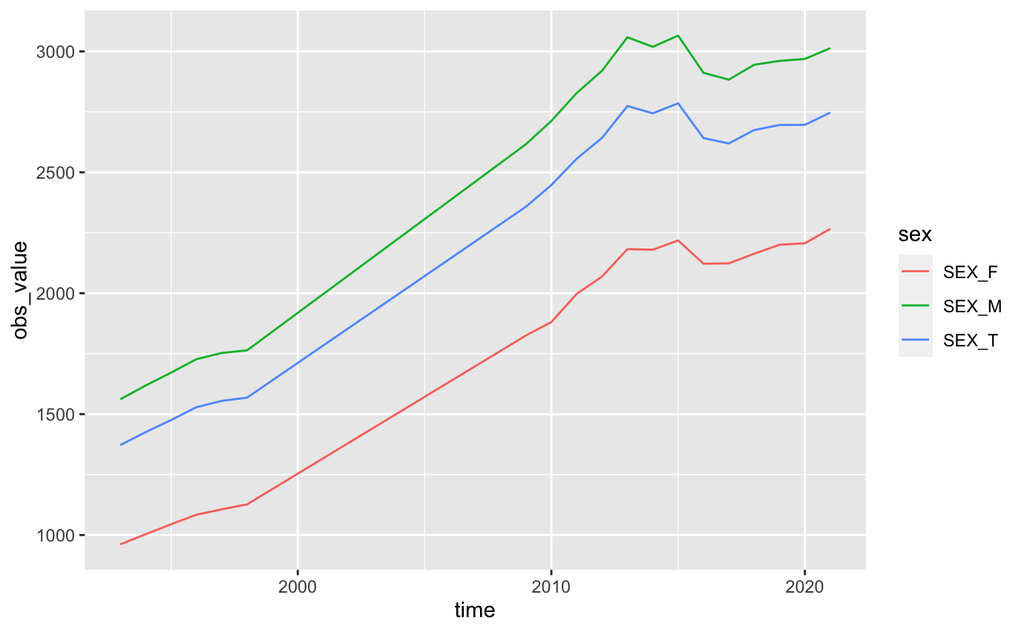

```r
df_ilo_wages |> filter(classif1 == "ECO_AGGREGATE_TOTAL", classif2 == "CUR_TYPE_PPP", ref_area == "JPN") |> mutate(time = as.numeric(time)) |>
  ggplot(aes(time, obs_value, color = sex)) + geom_line()
```

他の国の状況もみてみる。

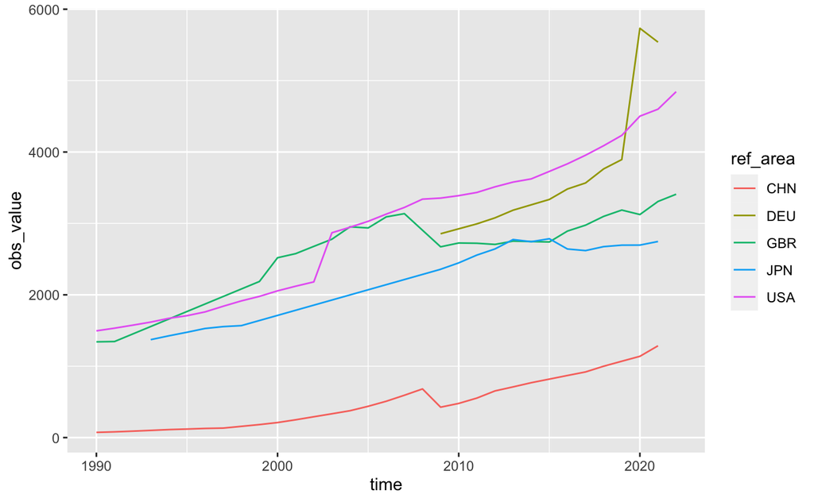

```r
df_ilo_wages |> filter(ref_area %in% c("JPN", "GBR", "DEU", "USA", "CHN")) |>
  filter(sex == "SEX_T") |>
  filter(classif1 == "ECO_AGGREGATE_TOTAL", classif2 == "CUR_TYPE_PPP") |>
  mutate(time = as.numeric(time)) |>
  ggplot(aes(time, obs_value, color = ref_area)) + geom_line()
```

### Import Data with an Option

type = “both” とすると、指標の内容も書かれていて、get_ilostat_dic() を使わなくて良いが、余分なものが多くて見にくい面もある。

```r
df_ilo_wages_both <- get_ilostat("EAR_4MTH_SEX_ECO_CUR_NB_A", type = "both", cache = FALSE)
df_ilo_wages_both
```

| ref_area | ref_area.label | source | source.label | indicator | indicator.label | sex | sex.label | classif1 | classif1.label | classif2 | classif2.label | time | obs_value | obs_status | obs_status.label | note_classif | note_classif.label | note_indicator | note_indicator.label | note_source | note_source.label |
| --- | --- | --- | --- | --- | --- | --- | --- | --- | --- | --- | --- | --- | --- | --- | --- | --- | --- | --- | --- | --- | --- |
| ABW | Aruba | AA:22 | PC - Population and Housing Census | EAR_4MTH_SEX_ECO_CUR_NB | Average monthly earnings of employees by sex and economic activity | SEX_T | Sex: Total | ECO_AGGREGATE_TOTAL | Economic activity (Aggregate): Total | CUR_TYPE_LCU | Currency: Local currency | 2010 | 3013.00 | NA | NA | NA | NA | T30:62_T11:142_T12:145_T33:396 | Currency: ABW - Florin (AWG) \| Job coverage: Main job currently held \| Working time arrangement coverage: Full-time and part time workers \| Working time concept: Hours actually worked | S3:20 | Data reference period: September |
| ABW | Aruba | AA:22 | PC - Population and Housing Census | EAR_4MTH_SEX_ECO_CUR_NB | Average monthly earnings of employees by sex and economic activity | SEX_T | Sex: Total | ECO_AGGREGATE_TOTAL | Economic activity (Aggregate): Total | CUR_TYPE_PPP | Currency: 2017 PPP $ | 2010 | 1860.38 | NA | NA | NA | NA | T30:62_T11:142_T12:145_T33:396 | Currency: ABW - Florin (AWG) \| Job coverage: Main job currently held \| Working time arrangement coverage: Full-time and part time workers \| Working time concept: Hours actually worked | S3:20 | Data reference period: September |
| ABW | Aruba | AA:22 | PC - Population and Housing Census | EAR_4MTH_SEX_ECO_CUR_NB | Average monthly earnings of employees by sex and economic activity | SEX_T | Sex: Total | ECO_AGGREGATE_TOTAL | Economic activity (Aggregate): Total | CUR_TYPE_USD | Currency: U.S. dollars | 2010 | 1683.24 | NA | NA | NA | NA | T30:62_T11:142_T12:145_T33:396 | Currency: ABW - Florin (AWG) \| Job coverage: Main job currently held \| Working time arrangement coverage: Full-time and part time workers \| Working time concept: Hours actually worked | S3:20 | Data reference period: September |
| ABW | Aruba | AA:22 | PC - Population and Housing Census | EAR_4MTH_SEX_ECO_CUR_NB | Average monthly earnings of employees by sex and economic activity | SEX_M | Sex: Male | ECO_AGGREGATE_TOTAL | Economic activity (Aggregate): Total | CUR_TYPE_LCU | Currency: Local currency | 2010 | 3338.00 | NA | NA | NA | NA | T30:62_T11:142_T12:145_T33:396 | Currency: ABW - Florin (AWG) \| Job coverage: Main job currently held \| Working time arrangement coverage: Full-time and part time workers \| Working time concept: Hours actually worked | S3:20 | Data reference period: September |
| ABW | Aruba | AA:22 | PC - Population and Housing Census | EAR_4MTH_SEX_ECO_CUR_NB | Average monthly earnings of employees by sex and economic activity | SEX_M | Sex: Male | ECO_AGGREGATE_TOTAL | Economic activity (Aggregate): Total | CUR_TYPE_PPP | Currency: 2017 PPP $ | 2010 | 2061.05 | NA | NA | NA | NA | T30:62_T11:142_T12:145_T33:396 | Currency: ABW - Florin (AWG) \| Job coverage: Main job currently held \| Working time arrangement coverage: Full-time and part time workers \| Working time concept: Hours actually worked | S3:20 | Data reference period: September |
| ABW | Aruba | AA:22 | PC - Population and Housing Census | EAR_4MTH_SEX_ECO_CUR_NB | Average monthly earnings of employees by sex and economic activity | SEX_M | Sex: Male | ECO_AGGREGATE_TOTAL | Economic activity (Aggregate): Total | CUR_TYPE_USD | Currency: U.S. dollars | 2010 | 1864.80 | NA | NA | NA | NA | T30:62_T11:142_T12:145_T33:396 | Currency: ABW - Florin (AWG) \| Job coverage: Main job currently held \| Working time arrangement coverage: Full-time and part time workers \| Working time concept: Hours actually worked | S3:20 | Data reference period: September |
| ABW | Aruba | AA:22 | PC - Population and Housing Census | EAR_4MTH_SEX_ECO_CUR_NB | Average monthly earnings of employees by sex and economic activity | SEX_F | Sex: Female | ECO_AGGREGATE_TOTAL | Economic activity (Aggregate): Total | CUR_TYPE_LCU | Currency: Local currency | 2010 | 2713.00 | NA | NA | NA | NA | T30:62_T11:142_T12:145_T33:396 | Currency: ABW - Florin (AWG) \| Job coverage: Main job currently held \| Working time arrangement coverage: Full-time and part time workers \| Working time concept: Hours actually worked | S3:20 | Data reference period: September |
| ABW | Aruba | AA:22 | PC - Population and Housing Census | EAR_4MTH_SEX_ECO_CUR_NB | Average monthly earnings of employees by sex and economic activity | SEX_F | Sex: Female | ECO_AGGREGATE_TOTAL | Economic activity (Aggregate): Total | CUR_TYPE_PPP | Currency: 2017 PPP $ | 2010 | 1675.15 | NA | NA | NA | NA | T30:62_T11:142_T12:145_T33:396 | Currency: ABW - Florin (AWG) \| Job coverage: Main job currently held \| Working time arrangement coverage: Full-time and part time workers \| Working time concept: Hours actually worked | S3:20 | Data reference period: September |
| ABW | Aruba | AA:22 | PC - Population and Housing Census | EAR_4MTH_SEX_ECO_CUR_NB | Average monthly earnings of employees by sex and economic activity | SEX_F | Sex: Female | ECO_AGGREGATE_TOTAL | Economic activity (Aggregate): Total | CUR_TYPE_USD | Currency: U.S. dollars | 2010 | 1515.64 | NA | NA | NA | NA | T30:62_T11:142_T12:145_T33:396 | Currency: ABW - Florin (AWG) \| Job coverage: Main job currently held \| Working time arrangement coverage: Full-time and part time workers \| Working time concept: Hours actually worked | S3:20 | Data reference period: September |
| ABW | Aruba | AA:22 | PC - Population and Housing Census | EAR_4MTH_SEX_ECO_CUR_NB | Average monthly earnings of employees by sex and economic activity | SEX_T | Sex: Total | ECO_ISIC3_TOTAL | Economic activity (ISIC-Rev.3.1): Total | CUR_TYPE_LCU | Currency: Local currency | 2010 | 3013.00 | NA | NA | NA | NA | T30:62_T11:142_T12:145_T33:396 | Currency: ABW - Florin (AWG) \| Job coverage: Main job currently held \| Working time arrangement coverage: Full-time and part time workers \| Working time concept: Hours actually worked | S3:20 | Data reference period: September |

[output cut: 990 more lines]

```r
colnames(df_ilo_wages_both)
```

```
 [1] "ref_area"             "ref_area.label"       "source"               "source.label"
 [5] "indicator"            "indicator.label"      "sex"                  "sex.label"
 [9] "classif1"             "classif1.label"       "classif2"             "classif2.label"
[13] "time"                 "obs_value"            "obs_status"           "obs_status.label"
[17] "note_classif"         "note_classif.label"   "note_indicator"       "note_indicator.label"
[21] "note_source"          "note_source.label"
```

```r
colnames(df_ilo_wages)
```

```
 [1] "ref_area"       "source"         "indicator"      "sex"            "classif1"
 [6] "classif2"       "time"           "obs_value"      "obs_status"     "note_classif"
[11] "note_indicator" "note_source"
```

### labor share of income

```r
get_ilostat_toc(search = 'income')
```

| id | indicator | indicator.label | freq | freq.label | size | data.start | data.end | last.update | n.records | collection | collection.label | subject | subject.label | database | database.label |
| --- | --- | --- | --- | --- | --- | --- | --- | --- | --- | --- | --- | --- | --- | --- | --- |
| SDG_1041_NOC_RT_A | SDG_1041_NOC_RT | SDG indicator 10.4.1 - Labour income share as a percent of GDP (%) | A | Annual | 17.93 KB | 2004 | 2020 | 22/04/2023 00:18:15 | 3383 | SDG | SDG labour market indicators (ILOSDG) | LAP | Labour income | ILOSDG | SDG Labour Market Indicators (ILOSDG) |
| LAP_2GDP_NOC_RT_A | LAP_2GDP_NOC_RT | Labour income share as a percent of GDP -- ILO modelled estimates, Nov. 2021 (%) | A | Annual | 24.16 KB | 2004 | 2020 | 21/04/2023 12:40:19 | 4607 | ILOEST | ILO modelled estimates (ILOEST) | LAP | Labour income | ILOEST | ILO Modelled Estimates (ILOEST) |
| LAP_2LID_QTL_RT_A | LAP_2LID_QTL_RT | Labour income distribution -- ILO modelled estimates, Nov. 2021 (%) | A | Annual | 240.86 KB | 2004 | 2020 | 21/04/2023 13:48:30 | 46070 | ILOEST | ILO modelled estimates (ILOEST) | LAP | Labour income | ILOEST | ILO Modelled Estimates (ILOEST) |
| LAP_2FTM_NOC_RT_A | LAP_2FTM_NOC_RT | Gender income gap, ratio of women's to men's labour income -- ILO modelled estimates, Nov. 2022 (%) | A | Annual | 7.54 KB | 2004 | 2020 | 21/04/2023 11:18:20 | 1394 | ILOEST | ILO modelled estimates (ILOEST) | LAP | Labour income | ILOEST | ILO Modelled Estimates (ILOEST) |

```r
id_income <- get_ilostat_toc(search = 'income') |> pull(id) |> unique()
id_income
```

```
[1] "SDG_1041_NOC_RT_A" "LAP_2GDP_NOC_RT_A" "LAP_2LID_QTL_RT_A" "LAP_2FTM_NOC_RT_A"
```

SDG_1041_NOC_RT_A: SDG indicator 10.4.1 - Labour income share as a percent of GDP (%)

```r
df_sdg_lis <- get_ilostat("SDG_1041_NOC_RT_A", cache = FALSE) |>
  mutate(time = as.numeric(time))
df_sdg_lis
```

| ref_area | source | indicator | time | obs_value |
| --- | --- | --- | --- | --- |
| AFG | XA:2198 | SDG_1041_NOC_RT | 2020 | 44.97 |
| AFG | XA:2198 | SDG_1041_NOC_RT | 2019 | 44.02 |
| AFG | XA:2198 | SDG_1041_NOC_RT | 2018 | 44.45 |
| AFG | XA:2198 | SDG_1041_NOC_RT | 2017 | 44.28 |
| AFG | XA:2198 | SDG_1041_NOC_RT | 2016 | 44.37 |
| AFG | XA:2198 | SDG_1041_NOC_RT | 2015 | 44.52 |
| AFG | XA:2198 | SDG_1041_NOC_RT | 2014 | 44.37 |
| AFG | XA:2198 | SDG_1041_NOC_RT | 2013 | 43.99 |
| AFG | XA:2198 | SDG_1041_NOC_RT | 2012 | 42.98 |
| AFG | XA:2198 | SDG_1041_NOC_RT | 2011 | 44.81 |

[output cut: 990 more lines]

LAP_2GDP_NOC_RT_A: Labour income share as a percent of GDP -- ILO modelled estimates, Nov. 2021 (%)

```r
df_income_dist <- get_ilostat("LAP_2GDP_NOC_RT_A", cache = FALSE) |>
  mutate(time = as.numeric(time))
df_income_dist
```

| ref_area | source | indicator | time | obs_value | obs_status |
| --- | --- | --- | --- | --- | --- |
| AFG | XA:2198 | LAP_2GDP_NOC_RT | 2020 | 44.97 | I |
| AFG | XA:2198 | LAP_2GDP_NOC_RT | 2019 | 44.02 | I |
| AFG | XA:2198 | LAP_2GDP_NOC_RT | 2018 | 44.45 | I |
| AFG | XA:2198 | LAP_2GDP_NOC_RT | 2017 | 44.28 | I |
| AFG | XA:2198 | LAP_2GDP_NOC_RT | 2016 | 44.37 | I |
| AFG | XA:2198 | LAP_2GDP_NOC_RT | 2015 | 44.52 | I |
| AFG | XA:2198 | LAP_2GDP_NOC_RT | 2014 | 44.37 | I |
| AFG | XA:2198 | LAP_2GDP_NOC_RT | 2013 | 43.99 | I |
| AFG | XA:2198 | LAP_2GDP_NOC_RT | 2012 | 42.98 | I |
| AFG | XA:2198 | LAP_2GDP_NOC_RT | 2011 | 44.81 | I |

[output cut: 990 more lines]

LAP_2LID_QTL_RT_A: Labour income distribution – ILO modelled estimates, Nov. 2021 (%)

```r
df_labor_income_share <- get_ilostat("LAP_2LID_QTL_RT_A", cache = FALSE) |>
  mutate(time = as.numeric(time))
df_labor_income_share
```

| ref_area | source | indicator | classif1 | time | obs_value | obs_status |
| --- | --- | --- | --- | --- | --- | --- |
| AFG | XA:2198 | LAP_2LID_QTL_RT | QTL_DECILE_01 | 2020 | 0.51 | M |
| AFG | XA:2198 | LAP_2LID_QTL_RT | QTL_DECILE_02 | 2020 | 1.11 | M |
| AFG | XA:2198 | LAP_2LID_QTL_RT | QTL_DECILE_03 | 2020 | 1.79 | M |
| AFG | XA:2198 | LAP_2LID_QTL_RT | QTL_DECILE_04 | 2020 | 3.08 | M |
| AFG | XA:2198 | LAP_2LID_QTL_RT | QTL_DECILE_05 | 2020 | 5.00 | M |
| AFG | XA:2198 | LAP_2LID_QTL_RT | QTL_DECILE_06 | 2020 | 7.14 | M |
| AFG | XA:2198 | LAP_2LID_QTL_RT | QTL_DECILE_07 | 2020 | 10.39 | M |
| AFG | XA:2198 | LAP_2LID_QTL_RT | QTL_DECILE_08 | 2020 | 13.97 | M |
| AFG | XA:2198 | LAP_2LID_QTL_RT | QTL_DECILE_09 | 2020 | 19.27 | M |
| AFG | XA:2198 | LAP_2LID_QTL_RT | QTL_DECILE_10 | 2020 | 37.73 | M |

[output cut: 990 more lines]

```r
df_gender_income_gap <- get_ilostat("LAP_2GDP_NOC_RT_A", cache = FALSE) |>
  mutate(time = as.numeric(time))
df_gender_income_gap
```

| ref_area | source | indicator | time | obs_value | obs_status |
| --- | --- | --- | --- | --- | --- |
| AFG | XA:2198 | LAP_2GDP_NOC_RT | 2020 | 44.97 | I |
| AFG | XA:2198 | LAP_2GDP_NOC_RT | 2019 | 44.02 | I |
| AFG | XA:2198 | LAP_2GDP_NOC_RT | 2018 | 44.45 | I |
| AFG | XA:2198 | LAP_2GDP_NOC_RT | 2017 | 44.28 | I |
| AFG | XA:2198 | LAP_2GDP_NOC_RT | 2016 | 44.37 | I |
| AFG | XA:2198 | LAP_2GDP_NOC_RT | 2015 | 44.52 | I |
| AFG | XA:2198 | LAP_2GDP_NOC_RT | 2014 | 44.37 | I |
| AFG | XA:2198 | LAP_2GDP_NOC_RT | 2013 | 43.99 | I |
| AFG | XA:2198 | LAP_2GDP_NOC_RT | 2012 | 42.98 | I |
| AFG | XA:2198 | LAP_2GDP_NOC_RT | 2011 | 44.81 | I |

[output cut: 990 more lines]

4つの指標一度に取ることも可能。

```r
df_income <- get_ilostat(c("SDG_1041_NOC_RT_A", "LAP_2GDP_NOC_RT_A", "LAP_2LID_QTL_RT_A", "LAP_2FTM_NOC_RT_A"), cache = FALSE) |>
  mutate(time = as.numeric(time))
df_income
```

| ref_area | source | indicator | classif1 | time | obs_value | obs_status |
| --- | --- | --- | --- | --- | --- | --- |
| AFG | XA:2198 | SDG_1041_NOC_RT | NA | 2020 | 44.97 | NA |
| AFG | XA:2198 | SDG_1041_NOC_RT | NA | 2019 | 44.02 | NA |
| AFG | XA:2198 | SDG_1041_NOC_RT | NA | 2018 | 44.45 | NA |
| AFG | XA:2198 | SDG_1041_NOC_RT | NA | 2017 | 44.28 | NA |
| AFG | XA:2198 | SDG_1041_NOC_RT | NA | 2016 | 44.37 | NA |
| AFG | XA:2198 | SDG_1041_NOC_RT | NA | 2015 | 44.52 | NA |
| AFG | XA:2198 | SDG_1041_NOC_RT | NA | 2014 | 44.37 | NA |
| AFG | XA:2198 | SDG_1041_NOC_RT | NA | 2013 | 43.99 | NA |
| AFG | XA:2198 | SDG_1041_NOC_RT | NA | 2012 | 42.98 | NA |
| AFG | XA:2198 | SDG_1041_NOC_RT | NA | 2011 | 44.81 | NA |

[output cut: 990 more lines]

```r
df_income$indicator |> unique()
```

```
[1] "SDG_1041_NOC_RT" "LAP_2GDP_NOC_RT" "LAP_2LID_QTL_RT" "LAP_2FTM_NOC_RT"
```

```r
id_income
```

```
[1] "SDG_1041_NOC_RT_A" "LAP_2GDP_NOC_RT_A" "LAP_2LID_QTL_RT_A" "LAP_2FTM_NOC_RT_A"
```

```r
df_income |> filter(ref_area == "JPN", time == 2020) |> select(2,3,4,7) |>
  lapply(unique)
```

```
$source
[1] "XA:1843"

$indicator
[1] "SDG_1041_NOC_RT" "LAP_2GDP_NOC_RT" "LAP_2LID_QTL_RT"

$classif1
 [1] NA              "QTL_DECILE_01" "QTL_DECILE_02" "QTL_DECILE_03" "QTL_DECILE_04"
 [6] "QTL_DECILE_05" "QTL_DECILE_06" "QTL_DECILE_07" "QTL_DECILE_08" "QTL_DECILE_09"
[11] "QTL_DECILE_10"

$obs_status
[1] NA  "M"
```

```r
get_ilostat_dic("classif1") |> filter(grepl("QTL_DECILE", classif1))
```

| classif1 | classif1.label |
| --- | --- |
| QTL_DECILE_01 | Decile: Decile 1 |
| QTL_DECILE_02 | Decile: Decile 2 |
| QTL_DECILE_03 | Decile: Decile 3 |
| QTL_DECILE_04 | Decile: Decile 4 |
| QTL_DECILE_05 | Decile: Decile 5 |
| QTL_DECILE_06 | Decile: Decile 6 |
| QTL_DECILE_07 | Decile: Decile 7 |
| QTL_DECILE_08 | Decile: Decile 8 |
| QTL_DECILE_09 | Decile: Decile 9 |
| QTL_DECILE_10 | Decile: Decile 10 |

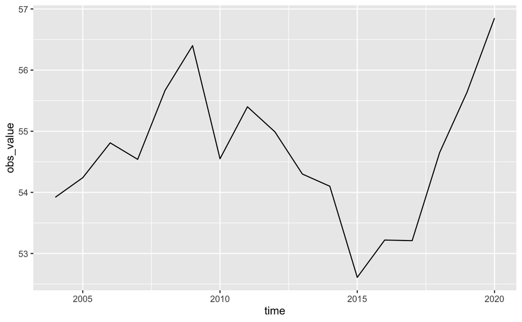

```r
df_income |> filter(ref_area == "JPN", indicator == "SDG_1041_NOC_RT") |>
  ggplot(aes(time, obs_value)) + geom_line()
```

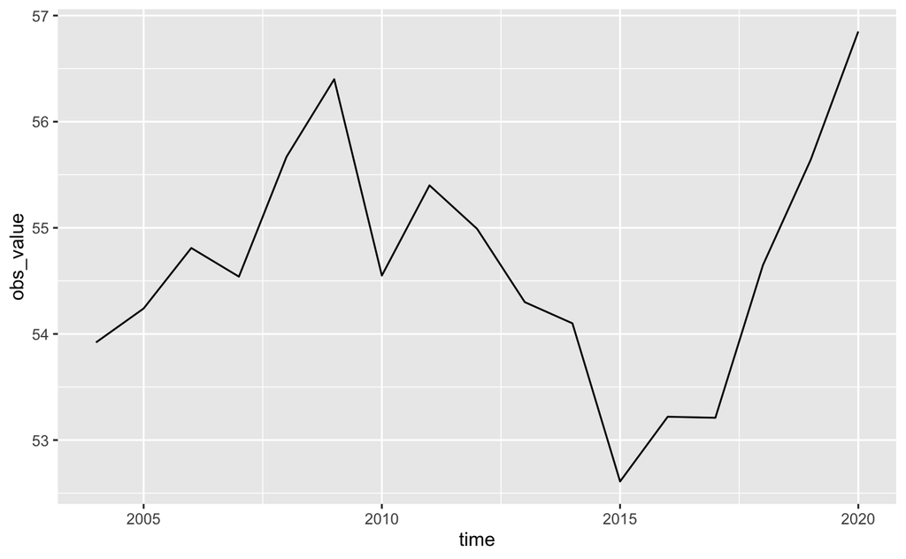

```r
df_income |> filter(ref_area == "JPN", indicator == "LAP_2GDP_NOC_RT") |>
  ggplot(aes(time, obs_value)) + geom_line()
```

2つの指標とも同じようです。

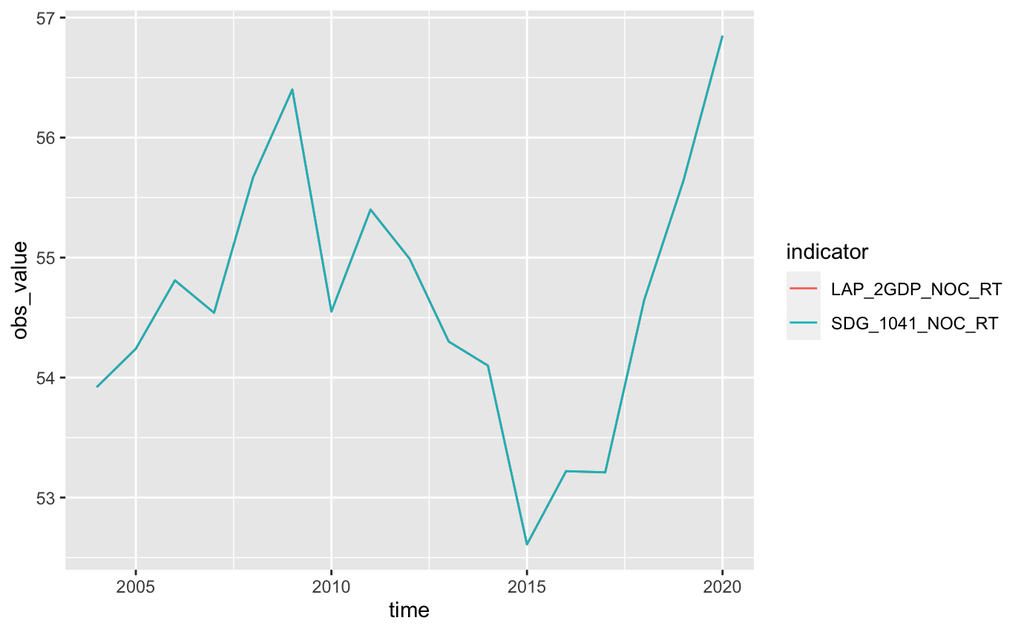

```r
df_income |> filter(ref_area == "JPN", indicator != "LAP_2LID_QTL_RT") |>
  ggplot(aes(time, obs_value, col = indicator)) + geom_line()
```

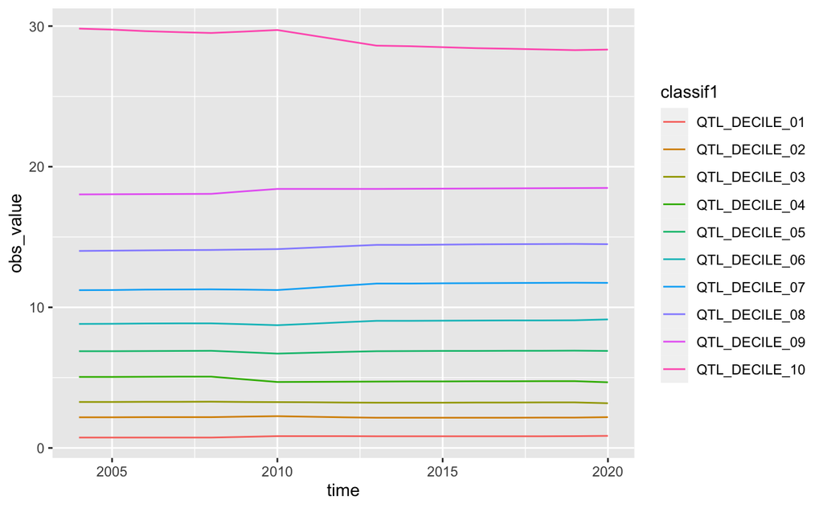

```r
df_income |> filter(ref_area == "JPN", indicator == "LAP_2LID_QTL_RT") |>
  ggplot(aes(time, obs_value, col = classif1)) + geom_line()
```

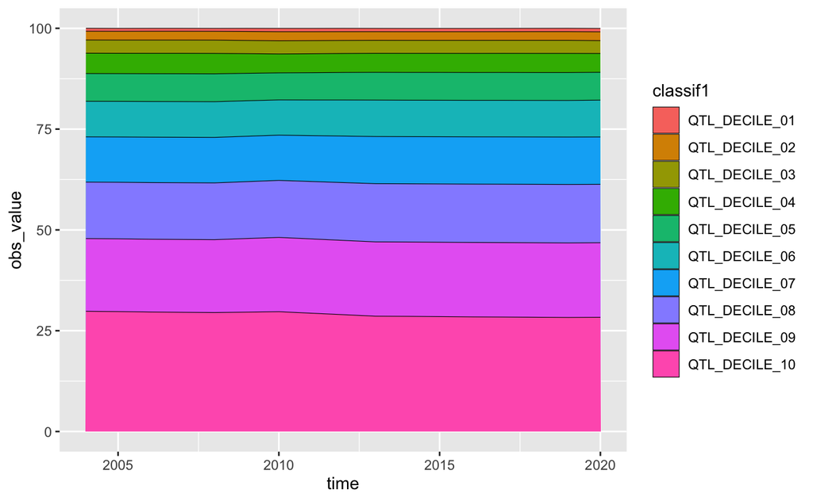

```r
df_income |> filter(ref_area == "JPN", indicator == "LAP_2LID_QTL_RT") |>
  ggplot(aes(time, obs_value, fill = classif1)) + geom_area(col = "black", linewidth = 0.2)
```

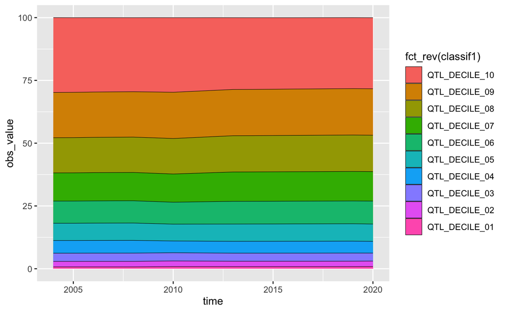

```r
df_income |> filter(ref_area == "JPN", indicator == "LAP_2LID_QTL_RT") |>
  ggplot(aes(time, obs_value, fill = fct_rev(classif1))) + geom_area(col = "black", linewidth = 0.2)
```